# Summary of methods

DEP AGREEMENT NO. CZ325 Deliverable 2b (Radiocarbon sample size for age and time-averaging determination) In this notebook, we summarize the simulation results for each of the methods and each of the localities. All of the RDS files are produced by separate notebooks. There are separate versions of for the ad hoc methods and the non-parametric method of Heaton.

These files are used for simulations using ad hoc methods. “Old_New_GR.Rmd” “Old_New PC.Rmd” “Old_New GI_EC_R2.Rmd” “Old_New GI_EC_R4.Rmd”

These files are used for simulations using Heaton’s nonparametric methods. “GR_Heaton.Rmd” “PC_Heaton.Rmd” “GI_EC_R2_Heaton.Rmd” “GI_EC_R4_Heaton.Rmd”

```r
library(tidyverse)
library(magrittr)
library(reshape2)
```

Read in results from original data and original curve N Median IQR_TAV IQR_CPE

```r
GR_original_estimates = readRDS("GR_original_estimates.RDS")
GR_original_estimates %<>% mutate(Locality = "Guana_River")

PC_original_estimates = readRDS("PC_original_estimates.RDS")
PC_original_estimates %<>% mutate(Locality = "Pellicer_Creek")

GI_EC_R2_original_estimates = readRDS("GI_EC_R2_original_estimates.RDS")
GI_EC_R2_original_estimates %<>% mutate(Locality = "Goose_Island_East_Cove_Reef_2")

GI_EC_R4_original_estimates = readRDS("GI_EC_R4_original_estimates.RDS")
GI_EC_R4_original_estimates %<>% mutate(Locality = "Goose_Island_East_Cove_Reef_4")

All_original_estimates = rbind(GR_original_estimates,PC_original_estimates,GI_EC_R2_original_estimates,GI_EC_R4_original_estimates)
```

Read in results of new curve but original data

```r
Guana_River_Old_Data_New_Curve_results = readRDS("Guana_River_Old_Data_New_Curve_results.RDS")
Guana_River_Old_Data_New_Curve_results %<>% mutate(Locality = "Guana_River")

Pellicer_Creek_Old_Data_New_Curve_results = readRDS("Pellicer_Creek_Old_Data_New_Curve_results.RDS")
Pellicer_Creek_Old_Data_New_Curve_results %<>% mutate(Locality = "Pellicer_Creek")

Goose_Island_East_Cove_R2H3S1_Old_Data_New_Curve_results = readRDS("Goose_Island_East_Cove_R2H3S1_Old_Data_New_Curve_results.RDS")
Goose_Island_East_Cove_R2H3S1_Old_Data_New_Curve_results %<>% mutate(Locality = "Goose_Island_East_Cove_Reef_2")

Goose_Island_East_Cove_R4H3S1_Old_Data_New_Curve_results = readRDS("Goose_Island_East_Cove_R4H3S1_Old_Data_New_Curve_results.RDS")
Goose_Island_East_Cove_R4H3S1_Old_Data_New_Curve_results %<>% mutate(Locality = "Goose_Island_East_Cove_Reef_4")

All_Old_Data_New_Curve_results = rbind(Guana_River_Old_Data_New_Curve_results,Pellicer_Creek_Old_Data_New_Curve_results,Goose_Island_East_Cove_R2H3S1_Old_Data_New_Curve_results,Goose_Island_East_Cove_R4H3S1_Old_Data_New_Curve_results)
```

Read in results of Heaton’s Nonparametric method

```r
Guana_River = readRDS("GR_All_NP_results.RDS")
Guana_River %<>% mutate(Locality = "Guana_River")

Pellicer_Creek = readRDS("PC_All_NP_results.RDS")
Pellicer_Creek %<>% mutate(Locality = "Pellicer_Creek")

Goose_Island_East_Cove_Reef_2 = readRDS("GI_EC_R2_All_NP_results.RDS")
Goose_Island_East_Cove_Reef_2 %<>% mutate(Locality = "Goose_Island_East_Cove_Reef_2")

Goose_Island_East_Cove_Reef_4 = readRDS("GI_EC_R4_All_NP_results.RDS")
Goose_Island_East_Cove_Reef_4 %<>% mutate(Locality = "Goose_Island_East_Cove_Reef_4")

All_NP = rbind(Guana_River,Pellicer_Creek,Goose_Island_East_Cove_Reef_2,Goose_Island_East_Cove_Reef_4)
```

Do some summary plots of the nonparametric methods for median age by Locality.

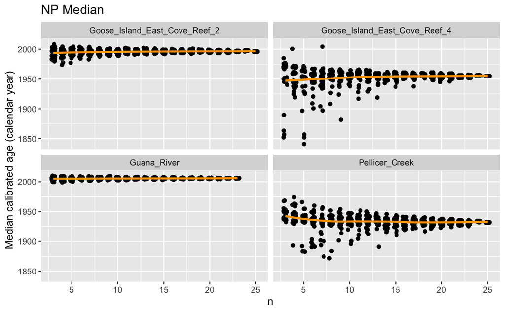

```r
All_NP  %>% ggplot(aes(x = n, y = Median)) + geom_jitter(width = 0.2) + geom_smooth(color = "orange") + facet_wrap(~Locality)  + ggtitle("NP Median") + ylab("Median calibrated age (calendar year)")
```

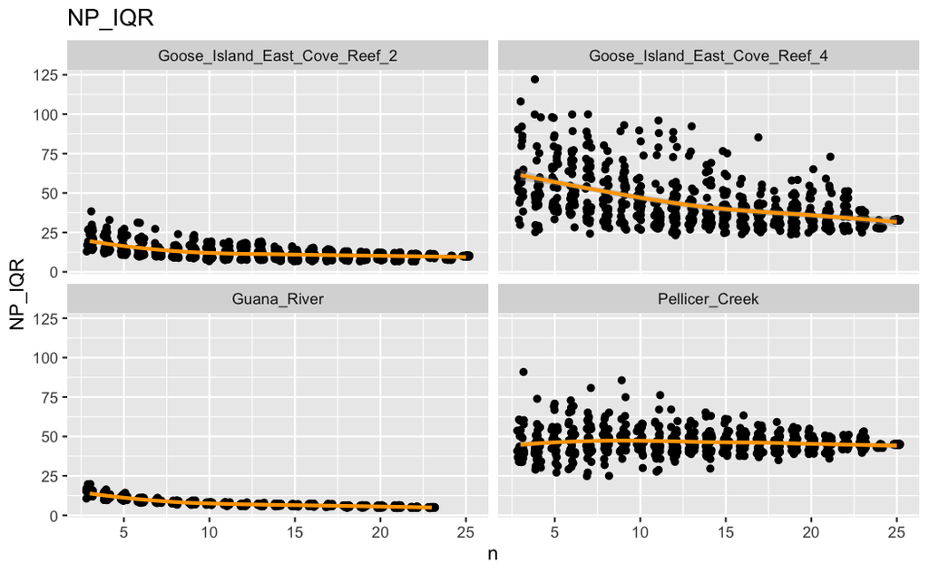

```r
All_NP  %>% ggplot(aes(x = n, y = NP_IQR)) + geom_jitter(width = 0.2) + geom_smooth(color = "orange") + facet_wrap(~Locality) + ggtitle("NP_IQR")
```

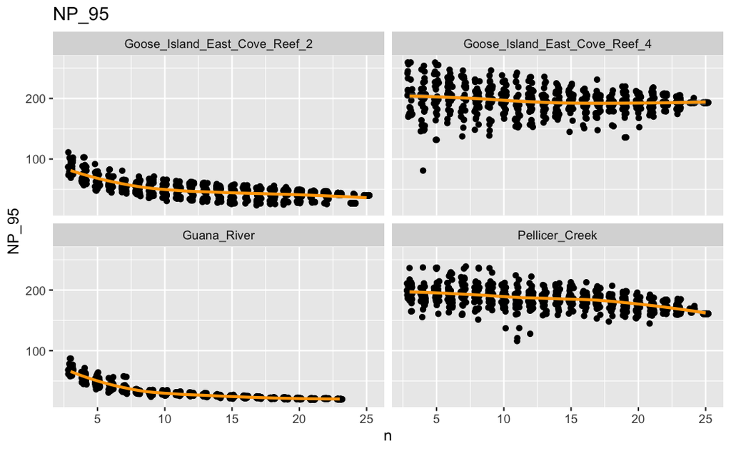

```r
All_NP  %>% ggplot(aes(x = n, y = NP_95)) + geom_jitter(width = 0.2) + geom_smooth(color = "orange") + facet_wrap(~Locality) + ggtitle("NP_95")
```

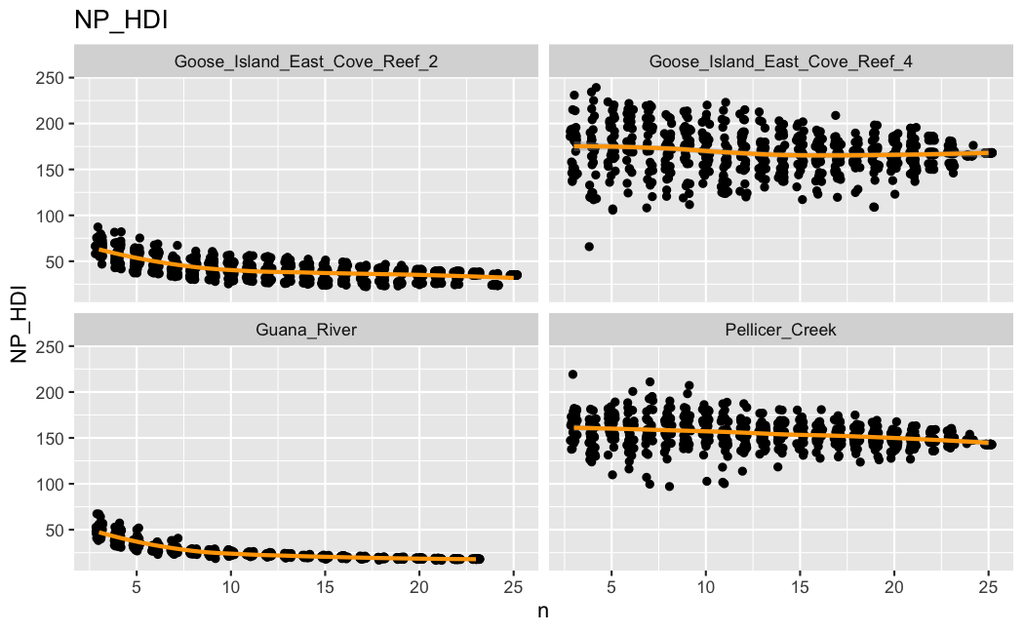

```r
All_NP  %>% ggplot(aes(x = n, y = NP_HDI)) + geom_jitter(width = 0.2) + geom_smooth(color = "orange") + facet_wrap(~Locality) + ggtitle("NP_HDI")
```

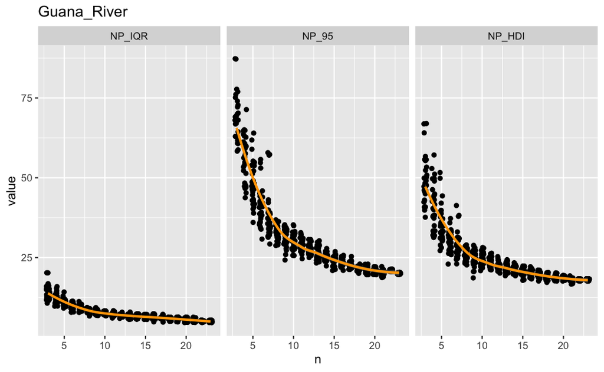

```r
All_NP  %>% filter(Locality == "Guana_River") %>% select(-Median, -Locality) %>% reshape2::melt("n") %>% group_by(variable) %>% ggplot(aes(x = n, y = value)) + geom_jitter(width = 0.2) + geom_smooth(color = "orange") + facet_wrap(~variable) + ggtitle("Guana_River")
```

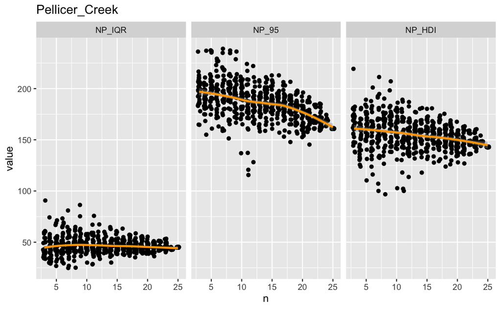

```r
All_NP  %>% filter(Locality == "Pellicer_Creek") %>% select(-Median, -Locality) %>% reshape2::melt("n") %>% group_by(variable) %>% ggplot(aes(x = n, y = value)) + geom_jitter(width = 0.2) + geom_smooth(color = "orange") + facet_wrap(~variable) + ggtitle("Pellicer_Creek")
```

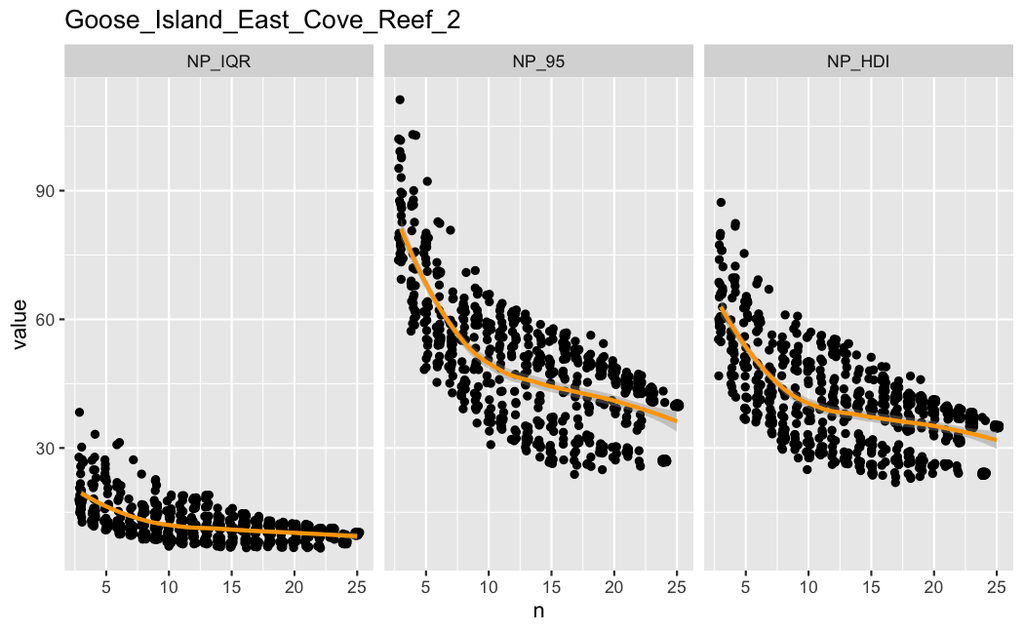

```r
All_NP  %>% filter(Locality == "Goose_Island_East_Cove_Reef_2") %>% select(-Median, -Locality) %>% reshape2::melt("n") %>% group_by(variable) %>% ggplot(aes(x = n, y = value)) + geom_jitter(width = 0.2) + geom_smooth(color = "orange") + facet_wrap(~variable) + ggtitle("Goose_Island_East_Cove_Reef_2")
```

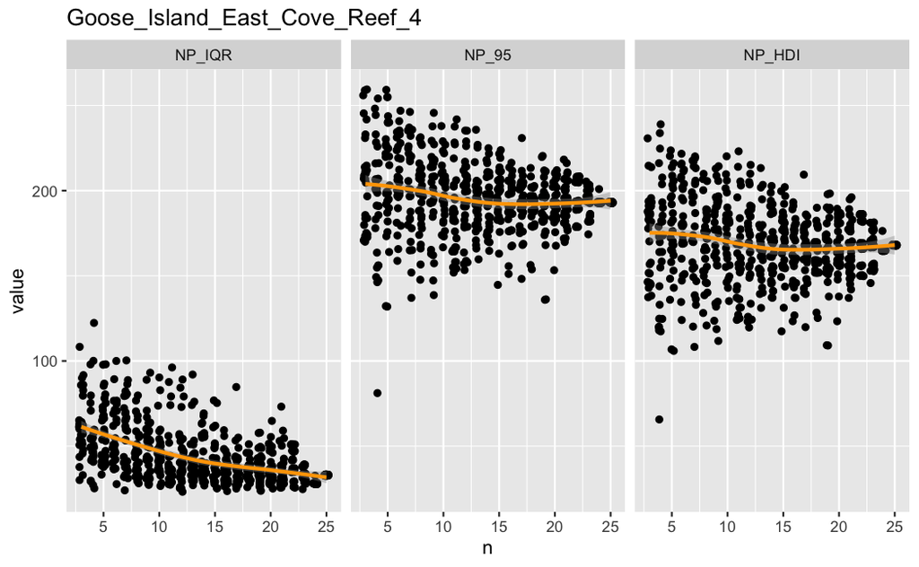

```r
All_NP  %>% filter(Locality == "Goose_Island_East_Cove_Reef_4") %>% select(-Median, -Locality) %>% reshape2::melt("n") %>% group_by(variable) %>% ggplot(aes(x = n, y = value)) + geom_jitter(width = 0.2) + geom_smooth(color = "orange") + facet_wrap(~variable) + ggtitle("Goose_Island_East_Cove_Reef_4")
```

Read in the ad hoc results

```r
Guana_River_R3H1S1_results = readRDS("Guana_River_R3H1S1_results.RDS")
Guana_River_R3H1S1_results %<>% mutate(Locality = "Guana_River")

Pellicer_Creek_R3H2S2_results = readRDS("Pellicer_Creek_R3H2S2_results.RDS")
Pellicer_Creek_R3H2S2_results %<>% mutate(Locality = "Pellicer_Creek")

Goose_Island_East_Cove_R2H3S1_results = readRDS("Goose_Island_East_Cove_R2H3S1_results.RDS")
Goose_Island_East_Cove_R2H3S1_results %<>% mutate(Locality = "Goose_Island_East_Cove_Reef_2")

Goose_Island_East_Cove_R4H3S1_results = readRDS("Goose_Island_East_Cove_R4H3S1_results.RDS")
Goose_Island_East_Cove_R4H3S1_results %<>% mutate(Locality = "Goose_Island_East_Cove_Reef_4")

All_ad_hoc_results = rbind(Guana_River_R3H1S1_results,Pellicer_Creek_R3H2S2_results,Goose_Island_East_Cove_R2H3S1_results,Goose_Island_East_Cove_R4H3S1_results)
```

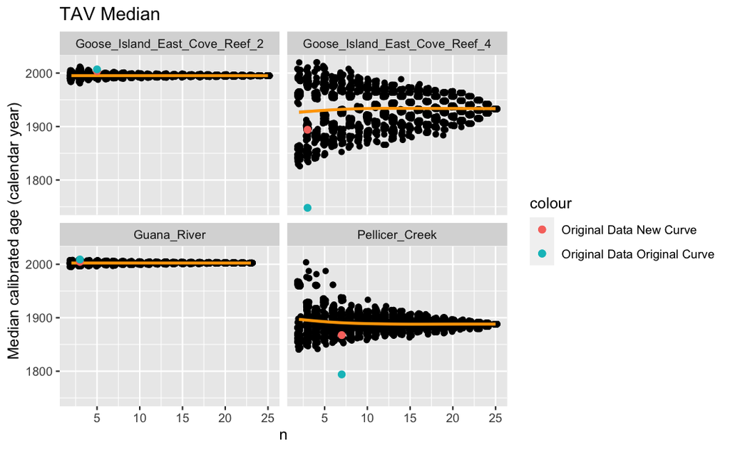

```r
All_ad_hoc_results %>% filter(Median <= 2023) %>% ggplot(aes(x = n, y = Median)) + geom_jitter(width = 0.2) + geom_smooth(color = "orange") +
  geom_point(data = All_Old_Data_New_Curve_results, aes( x  = n, y = Median, color = "Original Data New Curve"), size = 2) +
  geom_point(data = All_original_estimates, aes( x  = N, y = Median, color = "Original Data Original Curve"), size = 2) +
  facet_wrap(~Locality)  + ggtitle("TAV Median") + ylab("Median calibrated age (calendar year)")
```

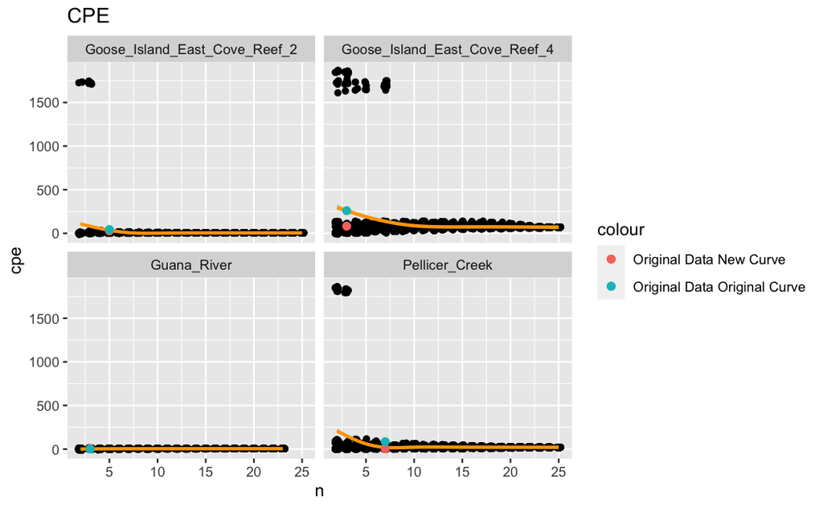

```r
All_ad_hoc_results %>% ggplot(aes(x = n, y = cpe)) + geom_jitter(width = 0.2) + geom_smooth(color = "orange") +
    geom_point(data = All_Old_Data_New_Curve_results, aes( x  = n, y = cpe, color = "Original Data New Curve"), size = 2) +
  geom_point(data = All_original_estimates, aes( x  = N, y = IQR_CPE, color = "Original Data Original Curve"), size = 2) +
  facet_wrap(~Locality)  + ggtitle("CPE")
```

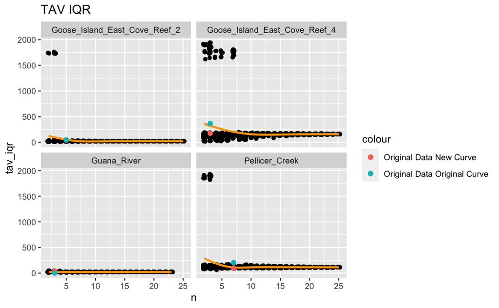

```r
All_ad_hoc_results %>% ggplot(aes(x = n, y = tav_iqr)) + geom_jitter(width = 0.2) + geom_smooth(color = "orange") +
    geom_point(data = All_Old_Data_New_Curve_results, aes( x  = n, y = tav_iqr, color = "Original Data New Curve"), size = 2) +
  geom_point(data = All_original_estimates, aes( x  = N, y = IQR_TAV, color = "Original Data Original Curve"), size = 2) +
  facet_wrap(~Locality)  + ggtitle("TAV IQR")
```

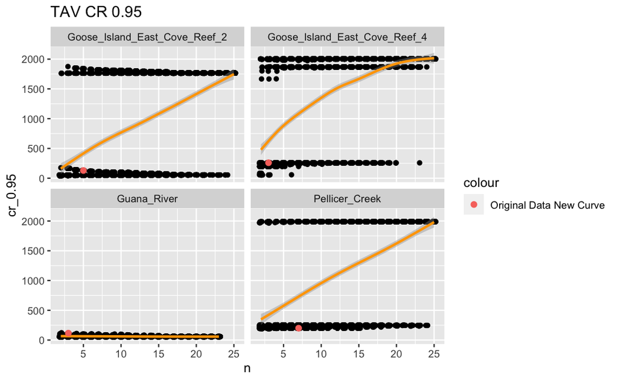

```r
All_ad_hoc_results %>% ggplot(aes(x = n, y = cr_0.95)) + geom_jitter(width = 0.2) + geom_smooth(color = "orange") +
    geom_point(data = All_Old_Data_New_Curve_results, aes( x  = n, y = cr_0.95, color = "Original Data New Curve"), size = 2) +
  facet_wrap(~Locality)  + ggtitle("TAV CR 0.95")
```

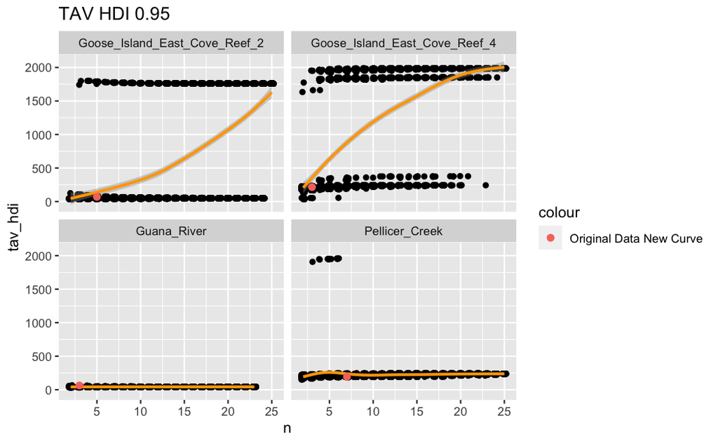

```r
All_ad_hoc_results %>% ggplot(aes(x = n, y = tav_hdi)) + geom_jitter(width = 0.2) + geom_smooth(color = "orange") +
    geom_point(data = All_Old_Data_New_Curve_results, aes( x  = n, y = tav_hdi, color = "Original Data New Curve"), size = 2) +
  facet_wrap(~Locality)  + ggtitle("TAV HDI 0.95")
```

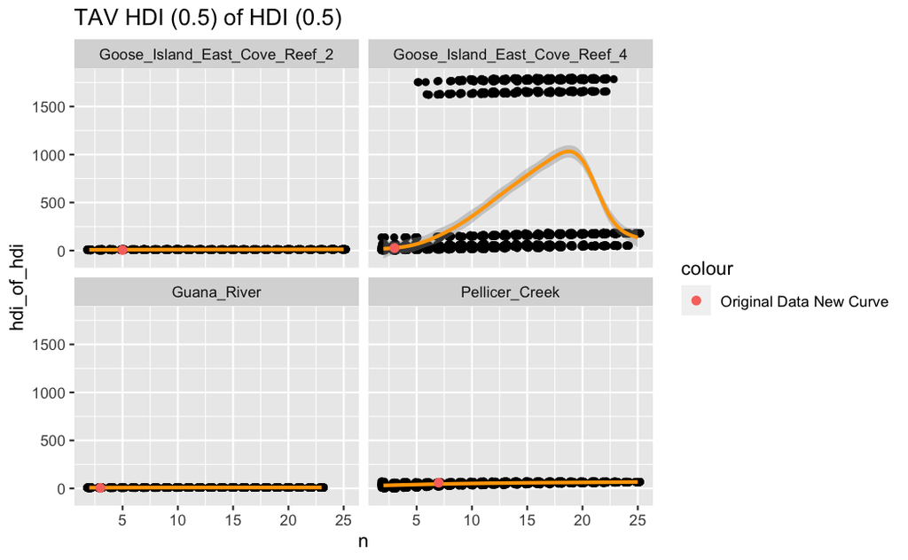

```r
All_ad_hoc_results %>% ggplot(aes(x = n, y = hdi_of_hdi)) + geom_jitter(width = 0.2) + geom_smooth(color = "orange") +
    geom_point(data = All_Old_Data_New_Curve_results, aes( x  = n, y = hdi_of_hdi, color = "Original Data New Curve"), size = 2) +
  facet_wrap(~Locality)  + ggtitle("TAV HDI (0.5) of HDI (0.5)")
```